# Администрирование сетевых подсистем

## Подключение каталогов для работы пользователей

Посмотрим права доступа установленные на этот каталог, common. Мы видим, что у него полные права доступа только для пользователя.

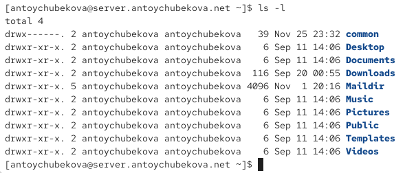

Права доступа

## Подключение каталогов для работы пользователей

Подключим каталог пользователя в файле /etc/exports.

[figure not shown]

Подключение каталога пользователя в /etc/exports

## Подключение каталогов для работы пользователей

Внесем изменения в файл /etc/fstab прописав, /home/user/common /srv/nfs/home/user none bind 0 0, котрая создает bind-монтирование /home/user/common в /srv/nfs/home/user.

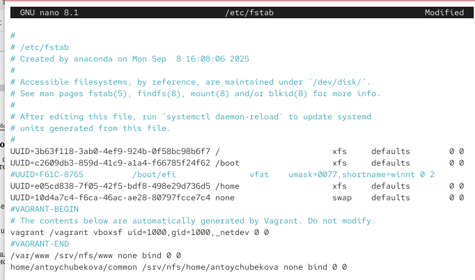

Создание bind-монтирование

## Подключение каталогов для работы пользователей

Повторно экспортируем каталоги. На клиенте проверим каталог /mnt/nfs. Мы видим, что появился каталог home.

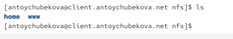

Содержимое каталога /mnt/nfs

## Подключение каталогов для работы пользователей

На клиенте под пользователем antoychubekova перейдем в каталог /mnt/nfs/home/antoychubekova и попробуем создать в нём файл antoychubekova@client.txt и внесем в него какие-либо изменения.

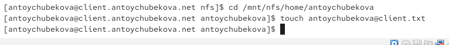

Изменение каталога /mnt/nfs/home

## Подключение каталогов для работы пользователей

Теперь попробуем проделать это под пользователем root. Мы видим, что в переходе и создании файла нам отказано в доступе.

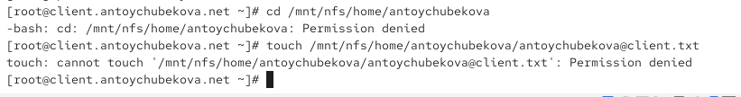

Изменение каталога /mnt/nfs/home под root

## Подключение каталогов для работы пользователей

На сервере посмотрим, появились ли изменения в каталоге пользователя /home/user/common. Мы видим, что появился файл который мы создали на клиенте.

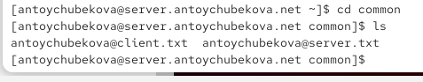

Проверка изменения каталога пользователя на сервере

## Внесение изменений в настройки внутреннего окружения виртуальных машин

На виртуальной машине server перейдем в каталог для внесения изменений в настройки внутреннего окружения /vagrant/provision/server/, создадим в нём каталог nfs, в который поместим в соответствующие подкаталоги конфигурационные файлы.

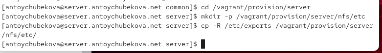

Внесение изменений в настройки внутреннего окружения виртуальных машин

## Внесение изменений в настройки внутреннего окружения виртуальных машин

В каталоге /vagrant/provision/server создадим исполняемый файл nfs.sh и добавим права для выполнения.

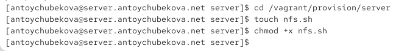

Создание исполняемого файла

## Внесение изменений в настройки внутреннего окружения виртуальных машин

Открыв его на редактирование, пропишем в нём соответствующий скрипт.

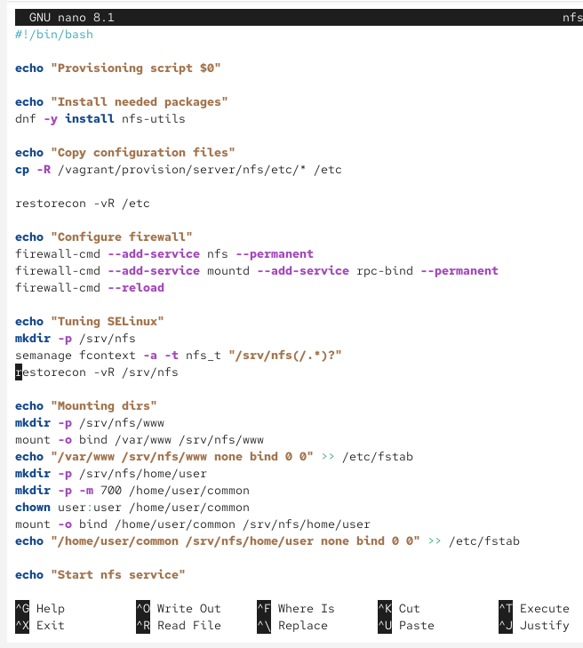

Редактирование исполняемого файла

## Внесение изменений в настройки внутреннего окружения виртуальных машин

На виртуальной машине client перейдем в каталог для внесения изменений в настройки внутреннего окружения /vagrant/provision/client/. В нем создадим исполняемый файл nfs.sh и присвоим ей права на выполнение.

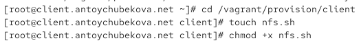

Создание исполняемого файла

## Внесение изменений в настройки внутреннего окружения виртуальных машин

Открыв его на редактирование, пропишем в нём соответствующий скрипт.

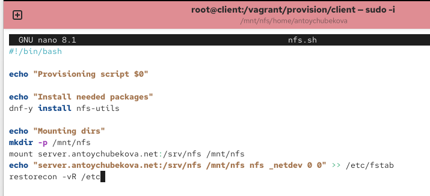

Редактирование исполняемого файла

## Внесение изменений в настройки внутреннего окружения виртуальных машин

Для отработки созданных скриптов во время загрузки виртуальных машин server и client в конфигурационном файле Vagrantfile необходимо добавить в соответствующих разделах конфигураций для сервера и клиента.

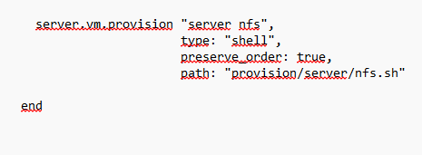

Редактирование Vagrantfile

## Внесение изменений в настройки внутреннего окружения виртуальных машин

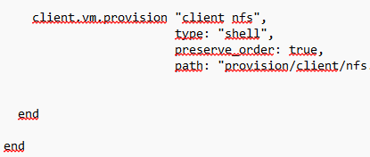

Редактирование Vagrantfile

# Выводы

## Вывод

В ходе выполнения лабораторной работы №13 я приобрела навыки настройки сервера NFS для удалённого доступа к ресурсам.